# EDA

Lingshan Wang

2025-07-26

## Load Libraries and Data

```r
library(dplyr)
```

```r
library(ggplot2)
library(naniar)
library(mice)
library(cluster)
# read data
data <- read.csv("data.csv", header = TRUE, stringsAsFactors = FALSE)

# view the data structure
summary(data)
```

```
##        X          treatment_group      gender            age
##  Min.   :   0.0   Min.   :0.0000   Min.   :0.0000   Min.   :60.00
##  1st Qu.: 624.8   1st Qu.:0.0000   1st Qu.:0.0000   1st Qu.:64.00
##  Median :1249.5   Median :1.0000   Median :1.0000   Median :68.00
##  Mean   :1249.5   Mean   :0.5072   Mean   :0.5068   Mean   :67.54
##  3rd Qu.:1874.2   3rd Qu.:1.0000   3rd Qu.:1.0000   3rd Qu.:71.00
##  Max.   :2499.0   Max.   :1.0000   Max.   :1.0000   Max.   :75.00
##
##  n_current_medications pain_score_baseline pain_score_final pain_score_diff
##  Min.   :1.00          Min.   :10.40       Min.   : 3.40    Min.   :-7.400
##  1st Qu.:2.00          1st Qu.:13.40       1st Qu.:12.00    1st Qu.:-0.400
##  Median :4.00          Median :14.00       Median :13.60    Median : 0.600
##  Mean   :3.64          Mean   :14.01       Mean   :12.98    Mean   : 1.045
##  3rd Qu.:5.00          3rd Qu.:14.60       3rd Qu.:14.60    3rd Qu.: 2.200
##  Max.   :7.00          Max.   :17.40       Max.   :20.00    Max.   :10.000
##                                            NA's   :260      NA's   :260
##  app_interactions  trial_centre   phyiscal_activity      bmi
##  Min.   : 0.00    Min.   :1.000   Min.   :0.0000    Min.   :21.90
##  1st Qu.: 8.45    1st Qu.:1.000   1st Qu.:0.0570    1st Qu.:27.80
##  Median :15.14    Median :2.000   Median :0.2633    Median :29.40
##  Mean   :15.05    Mean   :1.988   Mean   :0.3325    Mean   :29.33
##  3rd Qu.:21.34    3rd Qu.:3.000   3rd Qu.:0.5807    3rd Qu.:30.90
##  Max.   :30.00    Max.   :3.000   Max.   :1.0000    Max.   :37.60
##  NA's   :1232                     NA's   :1232
##  treatment_guess
##  Min.   :0.0000
##  1st Qu.:0.0000
##  Median :1.0000
##  Mean   :0.5112
##  3rd Qu.:1.0000
##  Max.   :1.0000
##
```

```r
# Convert variable types

data <- data %>%
  mutate(
    treatment_group = factor(treatment_group, levels = c(0,1), labels = c("Control","Intervention")),
    gender = factor(gender, levels = c(0,1), labels = c("Male","Female")),
    trial_centre = factor(trial_centre, levels = c(1,2,3),
                          labels = c("Centre1","Centre2","Centre3"))
  )
```

## Missing Data Overview

```r
# Check missing value
colSums(is.na(data))
```

```
##                     X       treatment_group                gender
##                     0                     0                     0
##                   age n_current_medications   pain_score_baseline
##                     0                     0                     0
##      pain_score_final       pain_score_diff      app_interactions
##                   260                   260                  1232
##          trial_centre     phyiscal_activity                   bmi
##                     0                  1232                     0
##       treatment_guess
##                     0
```

```r
# Create a missing flag variable (for pain_score_final)
data$missing_final <- ifelse(is.na(data$pain_score_final), 1, 0)

#View the proportion of missing by treatment_group
data %>%
  group_by(treatment_group) %>%
  summarise(
    n_total = n(),
    n_missing = sum(missing_final),
    missing_rate = mean(missing_final)
  )
```

```
## # A tibble: 2 × 4
##   treatment_group n_total n_missing missing_rate
##   <fct>             <int>     <dbl>        <dbl>
## 1 Control            1232        87       0.0706
## 2 Intervention       1268       173       0.136
```

```r
# Overview of Missing values
miss_var_summary(data)
```

```
## # A tibble: 14 × 3
##    variable              n_miss pct_miss
##    <chr>                  <int>    <num>
##  1 app_interactions        1232     49.3
##  2 phyiscal_activity       1232     49.3
##  3 pain_score_final         260     10.4
##  4 pain_score_diff          260     10.4
##  5 X                          0      0
##  6 treatment_group            0      0
##  7 gender                     0      0
##  8 age                        0      0
##  9 n_current_medications      0      0
## 10 pain_score_baseline        0      0
## 11 trial_centre               0      0
## 12 bmi                        0      0
## 13 treatment_guess            0      0
## 14 missing_final              0      0
```

```r
#
data <- data %>%
  mutate(pain_score_diff = pain_score_final - pain_score_baseline)

#  MAR TEST(Logistic regression)
mar_model <- glm(missing_final ~ age + gender + bmi + treatment_group + pain_score_baseline, data = data, family = binomial)
# mar_model <- glm(is.na(pain_score_final) ~ age + gender + treatment_group, data = data, family = binomial)
summary(mar_model)
```

```
##
## Call:
## glm(formula = missing_final ~ age + gender + bmi + treatment_group +
##     pain_score_baseline, family = binomial, data = data)
##
## Coefficients:
##                             Estimate Std. Error z value Pr(>|z|)
## (Intercept)                 -1.95811    1.59017  -1.231   0.2182
## age                          0.01784    0.01432   1.246   0.2129
## genderFemale                 0.12757    0.14096   0.905   0.3655
## bmi                          0.01077    0.02881   0.374   0.7086
## treatment_groupIntervention  0.68922    0.14601   4.720 2.36e-06 ***
## pain_score_baseline         -0.15677    0.06577  -2.384   0.0171 *
## ---
## Signif. codes:  0 '***' 0.001 '**' 0.01 '*' 0.05 '.' 0.1 ' ' 1
##
## (Dispersion parameter for binomial family taken to be 1)
##
##     Null deviance: 1668.9  on 2499  degrees of freedom
## Residual deviance: 1631.3  on 2494  degrees of freedom
## AIC: 1643.3
##
## Number of Fisher Scoring iterations: 5
```

```r
# If all independent variables are not significant -> The missing values may satisfy the MAR hypothesis
```

Missing values in the primary outcome variable pain_score_final were present in both groups, with a higher proportion in the intervention group (13.6%) compared to the control group (7.1%). This pattern suggests that missingness may be differential by group, supporting the use of missing data diagnostics and appropriate handling strategies such as multiple imputation under the Missing At Random (MAR) assumption. A logistic regression model was fitted to assess the missingness mechanism of pain_score_final. The results showed that missingness was significantly associated with the treatment group (p < 0.001) and baseline pain score (p = 0.017), suggesting the missing data mechanism was consistent with Missing At Random (MAR). Thus, multiple imputation was used to address the missing values.

## Multiple Imputation

```r
# Prepare the dataset for interpolation
# Reserve the variables for interpolation prediction
imp_data_int <- data %>%
  select(pain_score_final, pain_score_diff, age, gender, bmi, pain_score_baseline, n_current_medications)

#  Run multiple interpolation
set.seed(123)
imp_int <- mice(imp_data_int, m = 5, method = "pmm", maxit = 50, seed = 500)
# Obtain a set of interpolated data
completed_int <- complete(imp_int, 1)

# Write the interpolation result back to dataset (only replace those two columns)
data$pain_score_final <- completed_int$pain_score_final
data$pain_score_diff <- completed_int$pain_score_diff

# Check the merged data
colSums(is.na(data))
```

```
##                     X       treatment_group                gender
##                     0                     0                     0
##                   age n_current_medications   pain_score_baseline
##                     0                     0                     0
##      pain_score_final       pain_score_diff      app_interactions
##                     0                     0                  1232
##          trial_centre     phyiscal_activity                   bmi
##                     0                  1232                     0
##       treatment_guess         missing_final
##                     0                     0
```

Multiple Imputation via chained equations (MICE) was used to impute missing values in the primary outcome variable pain_score_final, and its derivative pain_score_diff, under the MAR assumption supported by prior logistic regression. A total of five imputed datasets were generated over 50 iterations. The process successfully filled in all missing values for these two key variables, enabling complete-case modelling in subsequent statistical analyses.

## Distribution Checks

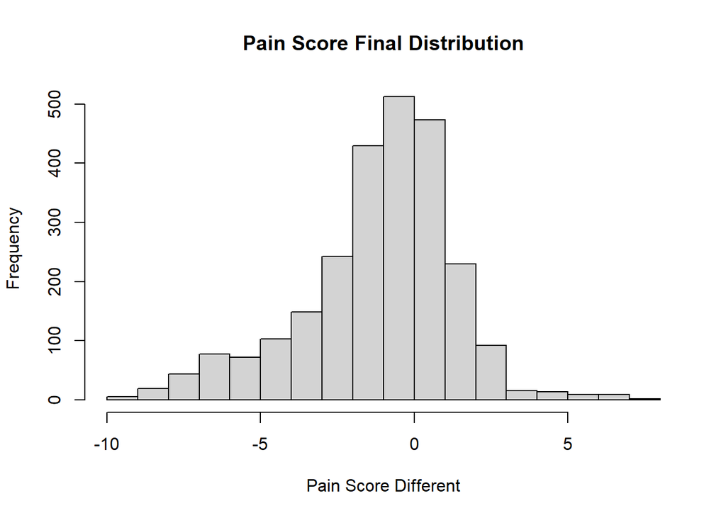

```r
# Histogram
hist(data$pain_score_diff, main="Pain Score Final Distribution", xlab="Pain Score Different")
```

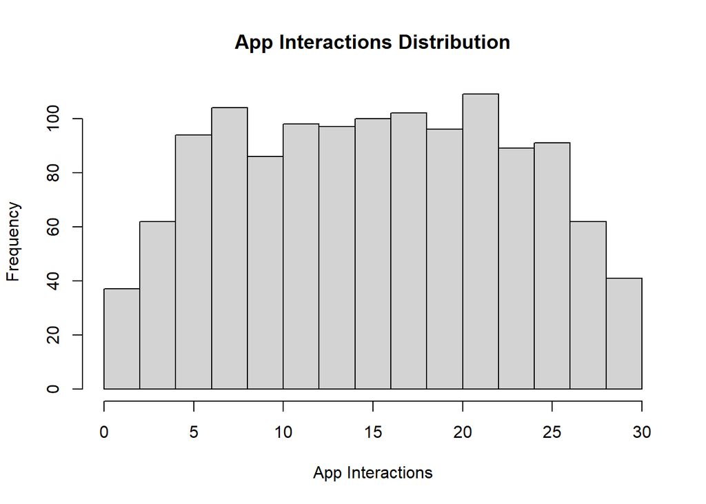

```r
hist(data$app_interactions, main="App Interactions Distribution", xlab="App Interactions")
```

```r
shapiro.test(data$app_interactions)
```

```
##
##  Shapiro-Wilk normality test
##
## data:  data$app_interactions
## W = 0.97245, p-value = 8.022e-15
```

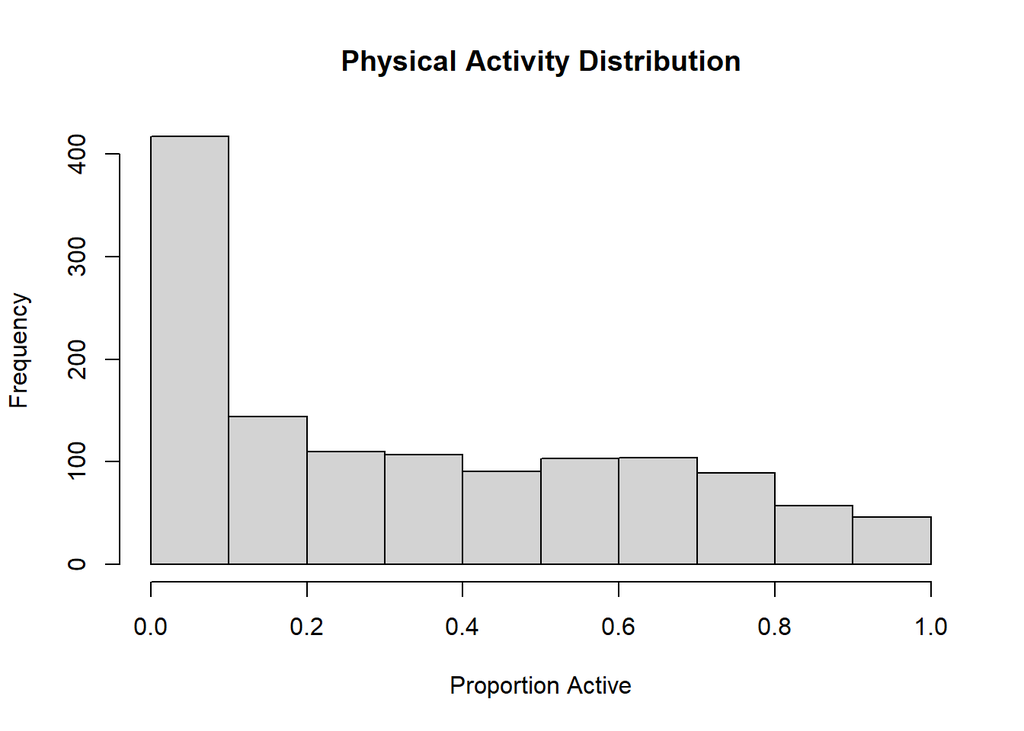

```r
hist(data$phyiscal_activity, main="Physical Activity Distribution", xlab="Proportion Active")
```

```r
shapiro.test(data$phyiscal_activity)
```

```
##
##  Shapiro-Wilk normality test
##
## data:  data$phyiscal_activity
## W = 0.90313, p-value < 2.2e-16
```

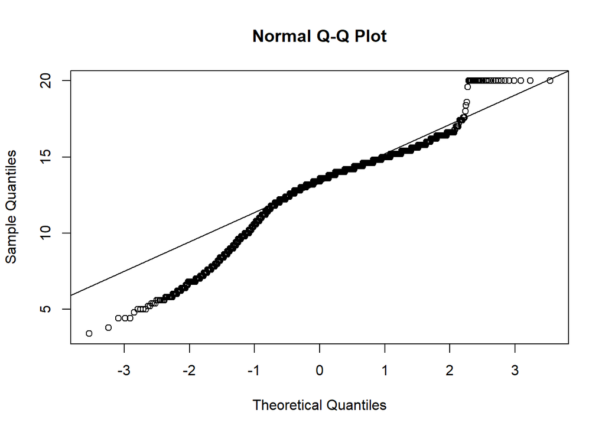

```r
# QQ plot
qqnorm(data$pain_score_final)
qqline(data$pain_score_final)
```

```r
# Shapiro-Wilk test for normality
shapiro.test(data$pain_score_final)
```

```
##
##  Shapiro-Wilk normality test
##
## data:  data$pain_score_final
## W = 0.93519, p-value < 2.2e-16
```

## Adherence and Outcome Relationship

```r
# Pearson correlation between app_interactions and pain_score_diff
cor.test(data$pain_score_final, data$app_interactions, use = "complete.obs")
```

```
##
##  Pearson's product-moment correlation
##
## data:  data$pain_score_final and data$app_interactions
## t = -17.568, df = 1266, p-value < 2.2e-16
## alternative hypothesis: true correlation is not equal to 0
## 95 percent confidence interval:
##  -0.4859291 -0.3973551
## sample estimates:
##        cor
## -0.4427215
```

```r
# Pearson correlation between physical_activity and pain_score_diff
cor.test(data$pain_score_final, data$phyiscal_activity, use = "complete.obs")
```

```
##
##  Pearson's product-moment correlation
##
## data:  data$pain_score_final and data$phyiscal_activity
## t = -16.636, df = 1266, p-value < 2.2e-16
## alternative hypothesis: true correlation is not equal to 0
## 95 percent confidence interval:
##  -0.4677004 -0.3773018
## sample estimates:
##       cor
## -0.423555
```

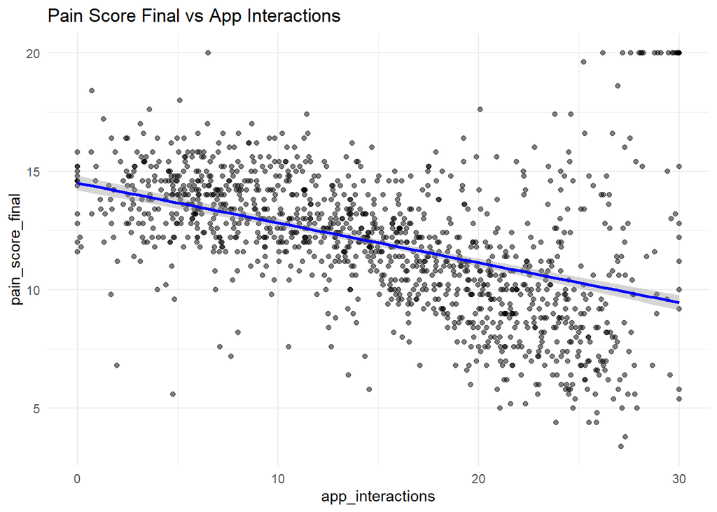

```r
# App interactions vs pain score diff
ggplot(data, aes(x = app_interactions, y = pain_score_final)) +
  geom_point(alpha = 0.5) +
  geom_smooth(method = "lm", color = "blue") +
  labs(title="Pain Score Final vs App Interactions") +
  theme_minimal()
```

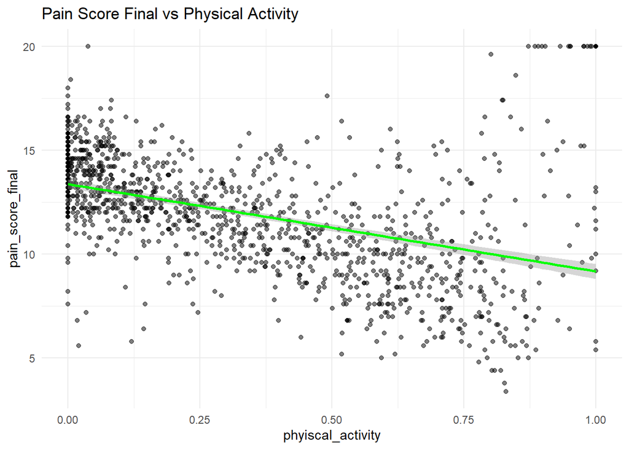

```r
# Physical activity vs pain score diff
ggplot(data, aes(x = phyiscal_activity, y = pain_score_final)) +
  geom_point(alpha = 0.5) +
  geom_smooth(method = "lm", color = "green") +
  labs(title="Pain Score Final vs Physical Activity") +
  theme_minimal()
```

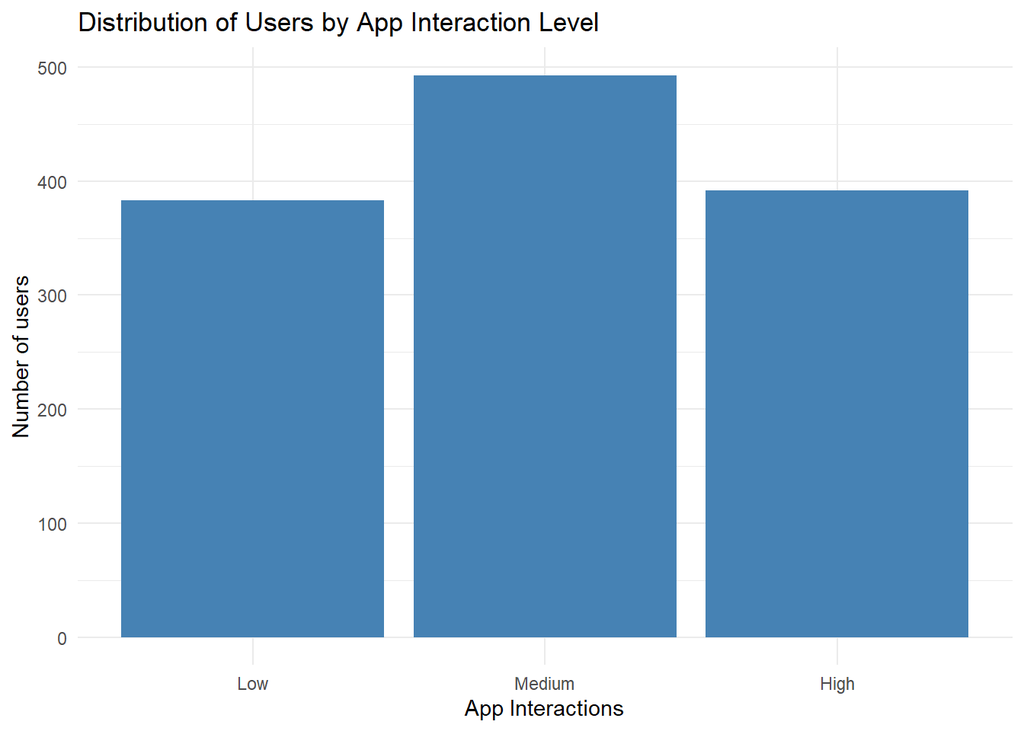

```r
data <- data %>%
  mutate(app_use_cat = cut(app_interactions,
                           breaks = 3,
                           labels = c("Low", "Medium", "High"),
                           include.lowest = TRUE))


intervention_data <- data %>%
  filter(treatment_group == "Intervention")
# 计算每档人数并画柱状图
ggplot(intervention_data, aes(x = app_use_cat)) +
  geom_bar(fill = "steelblue") +
  labs(x = "App Interactions",
       y = "Number of users",
       title = "Distribution of Users by App Interaction Level") +
  theme_minimal()
```

```r
# Regression model with adherence variables
model1 <- lm(pain_score_diff ~ app_interactions + age + gender + bmi, data = data)
summary(model1)
```

```
##
## Call:
## lm(formula = pain_score_diff ~ app_interactions + age + gender +
##     bmi, data = data)
##
## Residuals:
##     Min      1Q  Median      3Q     Max
## -6.4925 -1.2961 -0.0803  0.9926 11.8035
##
## Coefficients:
##                   Estimate Std. Error t value Pr(>|t|)
## (Intercept)       2.943743   1.372007   2.146   0.0321 *
## app_interactions -0.170723   0.009047 -18.871   <2e-16 ***
## age              -0.031633   0.014965  -2.114   0.0347 *
## genderFemale     -0.070262   0.146715  -0.479   0.6321
## bmi              -0.007060   0.030358  -0.233   0.8162
## ---
## Signif. codes:  0 '***' 0.001 '**' 0.01 '*' 0.05 '.' 0.1 ' ' 1
##
## Residual standard error: 2.455 on 1263 degrees of freedom
##   (因为不存在，1232个观察量被删除了)
## Multiple R-squared:  0.2204, Adjusted R-squared:  0.218
## F-statistic: 89.29 on 4 and 1263 DF,  p-value: < 2.2e-16
```

```r
model2 <- lm(pain_score_diff ~ phyiscal_activity + age + gender + bmi, data = data)
summary(model2)
```

```
##
## Call:
## lm(formula = pain_score_diff ~ phyiscal_activity + age + gender +
##     bmi, data = data)
##
## Residuals:
##     Min      1Q  Median      3Q     Max
## -7.0253 -1.3009 -0.1269  1.0418 12.1273
##
## Coefficients:
##                   Estimate Std. Error t value Pr(>|t|)
## (Intercept)        1.32926    1.37336   0.968   0.3333
## phyiscal_activity -4.28081    0.23805 -17.983   <2e-16 ***
## age               -0.02752    0.01510  -1.823   0.0686 .
## genderFemale      -0.01826    0.14817  -0.123   0.9019
## bmi               -0.00171    0.03068  -0.056   0.9556
## ---
## Signif. codes:  0 '***' 0.001 '**' 0.01 '*' 0.05 '.' 0.1 ' ' 1
##
## Residual standard error: 2.48 on 1263 degrees of freedom
##   (因为不存在，1232个观察量被删除了)
## Multiple R-squared:  0.2044, Adjusted R-squared:  0.2018
## F-statistic:  81.1 on 4 and 1263 DF,  p-value: < 2.2e-16
```

Both models suggest that behavioural engagement with the intervention—either via app usage or physical activity—is significantly associated with greater pain reduction, even when controlling for demographics. These exploratory findings highlight that adherence behaviour could partially explain the treatment effect, and may inform targeted engagement strategies or future per-protocol analysis.

## Kruskal-Wallis Test

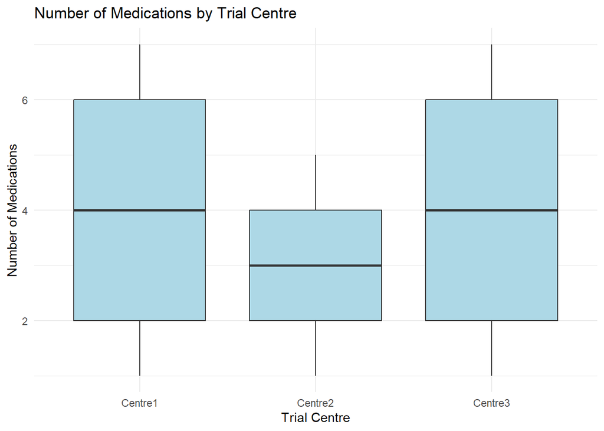

```r
# Boxplot for visual inspection
ggplot(data, aes(x = trial_centre, y = n_current_medications)) +
  geom_boxplot(fill = "lightblue") +
  labs(title = "Number of Medications by Trial Centre",
       x = "Trial Centre", y = "Number of Medications") +
  theme_minimal()
```

```r
# Kruskal-Wallis Test (non-parametric alternative to ANOVA)
kruskal.test(n_current_medications ~ trial_centre, data = data)
```

```
##
##  Kruskal-Wallis rank sum test
##
## data:  n_current_medications by trial_centre
## Kruskal-Wallis chi-squared = 163.35, df = 2, p-value < 2.2e-16
```

A Kruskal-Wallis test was conducted to examine differences in the number of medications used across the three trial centres. The results revealed a statistically significant difference between centres (χ²(2) = 163.35, p < 0.001), suggesting variability in participant medication burden across sites. This finding justifies consideration of trial centre as a stratification factor or subgroup in further analyses, especially in light of concerns regarding polypharmacy in the target population.

```r
write.csv(data, "imputed_data.csv", row.names = FALSE)
```

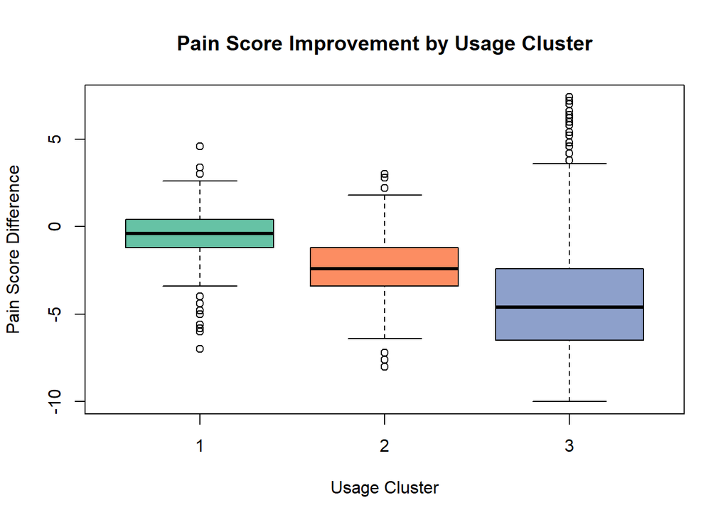

```r
# Extract individuals from the intervention group who have complete data usage
intervention_data <- data %>%
  filter(treatment_group == "Intervention") %>%
  select(app_interactions, phyiscal_activity) %>%
  na.omit()

# Standardize the data on app usage and activities
usage_data <- scale(intervention_data)

# Cluster analysis
set.seed(123)
k3 <- kmeans(usage_data, centers = 3)

# Add the clustering labels back to the original data
intervention_complete <- data %>%
  filter(treatment_group == "Intervention" &
         !is.na(app_interactions) &
         !is.na(phyiscal_activity)) %>%
  mutate(usage_cluster = factor(k3$cluster))

# box plot
boxplot(pain_score_diff ~ usage_cluster,
        data = intervention_complete,
        main = "Pain Score Improvement by Usage Cluster",
        xlab = "Usage Cluster", ylab = "Pain Score Difference",
        col = c("#66c2a5", "#fc8d62", "#8da0cb"))
```

This pattern suggests a dose-response relationship: higher usage of the intervention is associated with greater symptom improvement. The results support the idea that adherence and engagement with the digital tool play a critical role in its effectiveness.

## Harmful Effect Definition and Distribution

```r
# Add harm indicator across imputed datasets
imp <- data %>%
  mutate(harm = ifelse(pain_score_final > pain_score_baseline, 1, 0))

harm_summary <- imp %>%
  group_by(treatment_group, harm) %>%
  summarise(count = n(), .groups = "drop") %>%
  group_by(treatment_group) %>%
  mutate(percentage = round(count / sum(count) * 100, 1))

print(harm_summary)
```

```
## # A tibble: 4 × 4
## # Groups:   treatment_group [2]
##   treatment_group  harm count percentage
##   <fct>           <dbl> <int>      <dbl>
## 1 Control             0   646       52.4
## 2 Control             1   586       47.6
## 3 Intervention        0  1009       79.6
## 4 Intervention        1   259       20.4
```

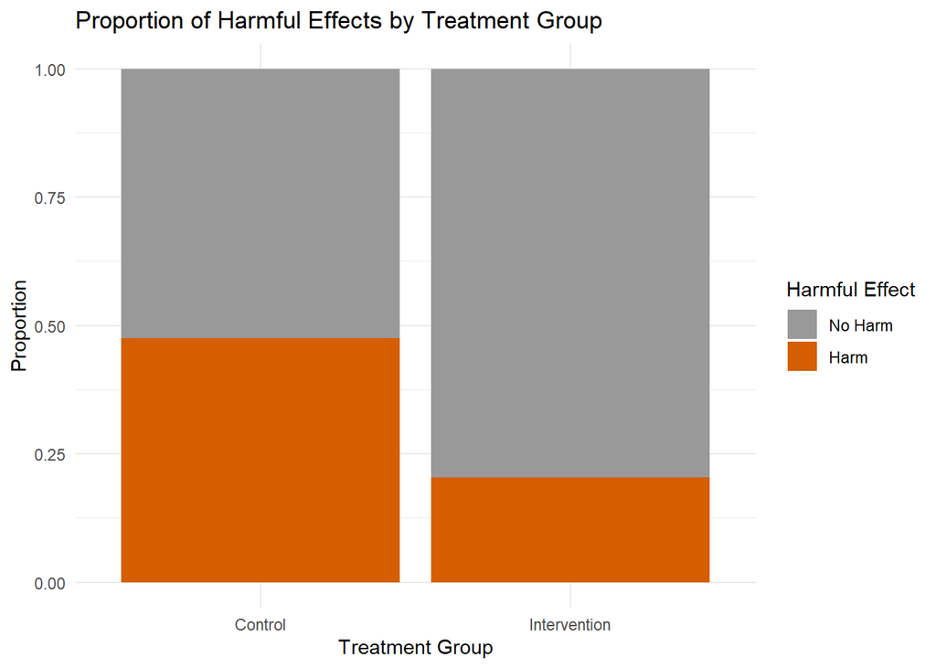

```r
ggplot(imp, aes(x = treatment_group, fill = factor(harm))) +
  geom_bar(position = "fill") +
  scale_fill_manual(values = c("#999999", "#D55E00"),
                    labels = c("No Harm", "Harm"),
                    name = "Harmful Effect") +
  labs(
    title = "Proportion of Harmful Effects by Treatment Group",
    x = "Treatment Group",
    y = "Proportion"
  ) +
  theme_minimal()
```

## Logistic Regression: Treatment Group and Harm

```r
# Logistic regression: does treatment group predict harm?
logit_model1 <- glm(harm ~ treatment_group + age + gender + trial_centre,
                    family = binomial, data = imp)

summary(logit_model1)
```

```
##
## Call:
## glm(formula = harm ~ treatment_group + age + gender + trial_centre,
##     family = binomial, data = imp)
##
## Coefficients:
##                              Estimate Std. Error z value Pr(>|z|)
## (Intercept)                 -1.380981   0.656543  -2.103   0.0354 *
## treatment_groupIntervention -1.230266   0.094996 -12.951   <2e-16 ***
## age                          0.018370   0.009605   1.912   0.0558 .
## genderFemale                -0.092903   0.093466  -0.994   0.3202
## trial_centreCentre2          0.034919   0.108634   0.321   0.7479
## trial_centreCentre3          0.180948   0.108177   1.673   0.0944 .
## ---
## Signif. codes:  0 '***' 0.001 '**' 0.01 '*' 0.05 '.' 0.1 ' ' 1
##
## (Dispersion parameter for binomial family taken to be 1)
##
##     Null deviance: 3198.5  on 2499  degrees of freedom
## Residual deviance: 2980.6  on 2494  degrees of freedom
## AIC: 2992.6
##
## Number of Fisher Scoring iterations: 4
```

```r
# OR and 95% CI
exp(cbind(OR = coef(logit_model1), confint(logit_model1)))
```

```
##                                    OR      2.5 %    97.5 %
## (Intercept)                 0.2513318 0.06925841 0.9088993
## treatment_groupIntervention 0.2922149 0.24228907 0.3516427
## age                         1.0185400 0.99955908 1.0379241
## genderFemale                0.9112819 0.75892981 1.0948665
## trial_centreCentre2         1.0355360 0.83689763 1.2813513
## trial_centreCentre3         1.1983525 0.96951029 1.4817296
```

## Logistic Regression: App Interactions vs Harmful effect

```r
# Subset intervention group
intervention_data <- imp %>%
  filter(treatment_group == "Intervention") %>%
  filter(!is.na(app_interactions) & !is.na(harm))

# Logistic regression: app usage and harm
logit_model2 <- glm(harm ~ app_interactions + age + gender + trial_centre,
                    family = binomial,
                    data = intervention_data)

summary(logit_model2)
```

```
##
## Call:
## glm(formula = harm ~ app_interactions + age + gender + trial_centre,
##     family = binomial, data = intervention_data)
##
## Coefficients:
##                      Estimate Std. Error z value Pr(>|z|)
## (Intercept)         -0.276618   1.101588  -0.251 0.801730
## app_interactions    -0.077479   0.010023  -7.730 1.07e-14 ***
## age                 -0.002914   0.015701  -0.186 0.852760
## genderFemale        -0.156015   0.151614  -1.029 0.303469
## trial_centreCentre2  0.191160   0.185070   1.033 0.301647
## trial_centreCentre3  0.600754   0.177145   3.391 0.000696 ***
## ---
## Signif. codes:  0 '***' 0.001 '**' 0.01 '*' 0.05 '.' 0.1 ' ' 1
##
## (Dispersion parameter for binomial family taken to be 1)
##
##     Null deviance: 1283.8  on 1267  degrees of freedom
## Residual deviance: 1203.7  on 1262  degrees of freedom
## AIC: 1215.7
##
## Number of Fisher Scoring iterations: 4
```

```r
# OR and 95% CI
exp(cbind(OR = coef(logit_model2), confint(logit_model2)))
```

```
##                            OR      2.5 %    97.5 %
## (Intercept)         0.7583440 0.08719998 6.5684744
## app_interactions    0.9254467 0.90719153 0.9435762
## age                 0.9970902 0.96683100 1.0282576
## genderFemale        0.8555467 0.63668898 1.1542149
## trial_centreCentre2 1.2106537 0.84272670 1.7426211
## trial_centreCentre3 1.8234937 1.29151520 2.5885024
```

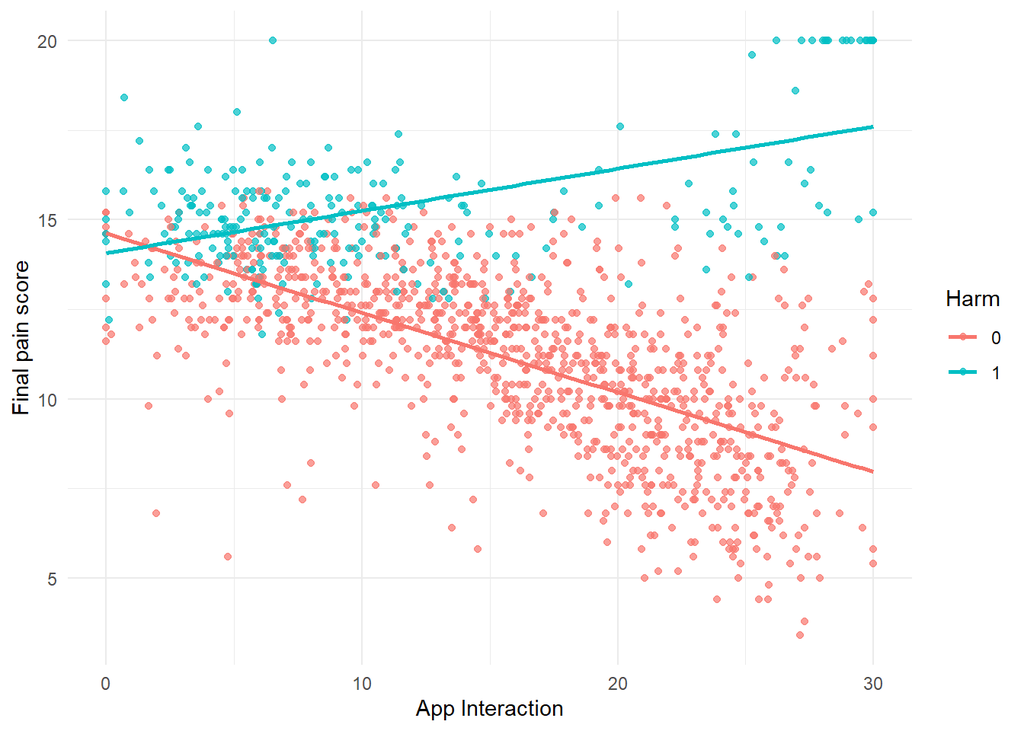

```r
# Density plot: harmful effect vs non-harmful effect by app usage
# harm_data <- imp %>%
#   filter(treatment_group == "Intervention", harm == 1) %>%
#   filter(!is.na(app_interactions), !is.na(pain_score_final))
#
#
#
# ggplot(harm_data, aes(x = app_interactions, fill = pain_band)) +
#   geom_density(alpha = 0.7) +
#   labs(
#     title = "Density of App Interactions (Harm Group Only)",
#     x = "Number of App Interactions",
#     y = "Density",
#     fill = "Final Pain Score Band"
#   ) +
#   theme_minimal()

# ggplot(imp, aes(x = app_interactions, fill = factor(harm))) +
#   geom_density(alpha = 0.4) +
#   scale_fill_manual(values = c("#999999", "#D55E00"),
#                     labels = c("No Harm", "Harm"),
#                     name = "Harmful Effect") +
#   labs(title = "Distribution of App Interactions by Harm Status",
#        x = "App Interactions",
#        y = "Density") +
#   theme_minimal()

ggplot(imp, aes(x = app_interactions, y = pain_score_final, color = factor(harm))) +
  geom_point(alpha = 0.7) +
  geom_smooth(method = "lm", se = FALSE) +   # 可选趋势线
  labs(x = "App Interaction", y = "Final pain score", color = "Harm") +
  theme_minimal()
```